# AN597_finalproject

# 3 Plotting PCA

Now time for some plotting. I transferred the new .vcf file to my local directory.

The authors say they use adegenet to make the PCA. In the next part of code I also use adegenet, but I think they had slightly different input data, perhaps genepop formatted data input rather than the .vcf that I use.

```r
#install.packages("vcfR")
suppressMessages(library(vcfR))
suppressMessages(library(adegenet))
suppressMessages(library(vegan))
#suppressMessages(library(stringr))

#convert vcf to a genlight object for plotting
gl=vcfR2genlight(read.vcfR("scallops.vcf"))
```

[output not shown]

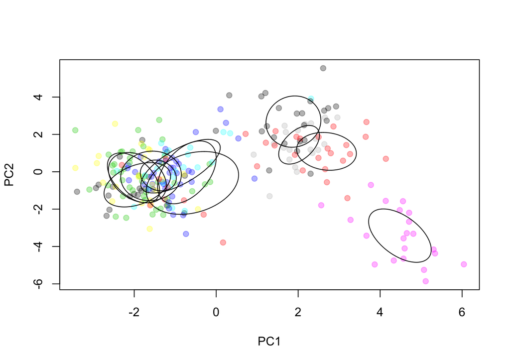

```r
#reading in population information
pops=read.table("pops.inds",sep="\t")

#assigning populations to the genlight object
pop(gl)=pops$V2

#make the pca
pca=glPca(gl,nf=3,parallel=F)
#nf means the number of principal components to retain, here we do 3
#parallel would just be a threads processing thing, not doing that here

#plotting
plot(pca$scores[,1:2],col=transp(as.numeric(as.factor(pop(gl))),0.3),pch=19)
ordiellipse(pca$scores[,1:2],pops$V2,label=F,draw="lines")
```

The authors’ PCA for comparison:

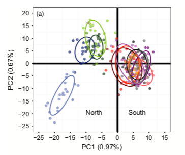

So I get the mirror image of the author’s figure for some reason. But the pattern holds: the one divergent site by itself, then three sites clustering together, and then all the other sites together in a big mess.

# 4 Expected heterozgyosity analysis

The authors report the expected heterozygosity average +/- the standard deviation. They said they used gstudio for that, but that requires the genepop format of the data, while I have a vcf, so I’m using hierfstat from a vcf to genind object instead because that’s what I could figure out how to use.

```r
library(hierfstat)
library(adegenet)

#read in the data
vcf <- read.vcfR("scallops.vcf")
```

[output not shown]

```r
#read in the population files
pop <- read.table("pops.inds")
#transform vcf file to genind object
genind <- vcfR2genind(vcf)
#assign populations
pop(genind) <- pop$V2

#calculate diversity statistics
div <- summary(genind)
#my attempts to extract just the expected heterozygosity data - there's definitely an easier way
het <- as.data.frame(div[["Hexp"]])
new <- c(het[1:7163,])
new2 <- as.data.frame(new)

#finally, the mean & standard deviation of the expected heterozygosity
mean(new2$new)
```

```
## [1] 0.2710147
```

```r
sd(new2$new)
```

```
## [1] 0.1332815
```

The authors reported the same thing as me: “expected heterozygosity averaged 0.2710 ± 0.1333 (mean ± SD)”